# Lesson_28_Boardsheet

Kevin Cummiskey

4/3/2020

## Review

What characteristics of a hitter does OPS quantify?

Why might one use OPS+ or adjusted OPS+ instead of OPS?

What are some limitations of these statistics?

## Linear Weights

Recall we talked about the relationship between Runs and Wins in Chapter 4 of the Marchi text. What was the rule of thumb we used?

(*Understanding Sabermetrics* pg 83) Ideally, we want a statistic for batters that:

- quantifies their contribution to runs scored.
- is not based upon the situations the batters faced when they came to the plate (since their batting actions did not create those situations).

How about RBI’s? A batter is awarded Runs Batted In (RBIs) for most situations when his plate appearance results in runs scored. Why are RBIs not a good measure of a player’s contribution to runs scored?

Various researchers have proposed linear models to quantify a player’s contribution to runs scored. These models weight individual statistics. For the purposes of today’s lesson, let’s investigate the condensed model proposed by Thorn and Palmer (*Understanding Sabermetrics*, pg 87). I’ll refer to this model as the Linear Weights Model

$$Batting Runs = w_1\text{1B} + w_2\text{2B} + w_3\text{3B} + w_4\text{HR} + w_5 (\text{BB}+\text{HBP}) - w_6(AB-H)$$

How can we get weights for the Linear Weights Model?

How do we interpret $Batting Runs$?

Let’s see what this looks like for the 2018 season.

```r
library(Lahman)
library(tidyverse)
library(plotly)
library(knitr)

# Calculate weights from run values using Retrosheet play-by-play data
# this code will only run if you have a 2018 retrosheet
# event-by-event data on your computer.
source("../MA388_Solutions/linear_weights.R")
weights <- linear_weights(2018) %>% pluck("weights")
weights %>% kable(digits = 3)
```

| Event | weight |
| --- | --- |
| 1B | 0.449 |
| 2B | 0.765 |
| 3B | 1.097 |
| BB.HBP | 0.303 |
| HR | 1.380 |
| Out | -0.265 |

How do these weights compare to those in slugging percentage (SLG)?

```r
# 2018 Players with at least 500 at bats
vars = c("AB", "H", "X2B", "X3B", "HR", "BB",
         "HBP", "SF","RBI")
Batting %>%
  filter(yearID == 2018) %>%
  group_by(playerID) %>%
  summarise_at(vars, sum) %>%
  filter(AB >= 500) %>%
  left_join(Master %>% select(nameLast,nameFirst,playerID)) %>%
  mutate(name = paste(nameFirst, nameLast, sep = " ")) %>%
  select(name, everything(), -nameLast,-nameFirst) %>%
  mutate(X1B = H - X2B - X3B - HR,
         SLG = (X1B + 2*X2B + 3*X3B + 4*HR)/AB,
         OBP = (H + HBP + BB)/(AB + HBP + SF + BB),
         OPS = SLG + OBP,
         AVG = H/AB) -> batting.2018

#calculates Batting Runs using Thorn and Palmer's condensed Linear Weights model.
#note statistics and weights have to be in the same order
batting_runs <- function(statistics, weights){
  runs <- round(sum(statistics*weights),1)
  return(runs)
}

batting.2018 %>%
  group_by(playerID) %>%
  mutate(batting.runs = batting_runs(statistics = c(X1B, X2B, X3B, BB + HBP, HR, AB - H),
                                     weights = weights %>% pull(weight))) %>%
  arrange(-batting.runs) %>%
  group_by()-> batting.2018

batting.2018 %>%
  select(name, AB, H, HR, RBI, AVG, OPS, batting.runs) %>%
  head(10) %>%
  kable(digits = 3,
        caption = "Top 10 MLB Players (with at least 500 at bats) - Batting Runs 2018")
```

Top 10 MLB Players (with at least 500 at bats) - Batting Runs 2018

| name | AB | H | HR | RBI | AVG | OPS | batting.runs |
| --- | --- | --- | --- | --- | --- | --- | --- |
| Mookie Betts | 520 | 180 | 32 | 80 | 0.346 | 1.078 | 65.4 |
| J. D. Martinez | 569 | 188 | 43 | 130 | 0.330 | 1.031 | 58.4 |
| Christian Yelich | 574 | 187 | 36 | 110 | 0.326 | 1.000 | 52.7 |
| Jose Ramirez | 578 | 156 | 39 | 105 | 0.270 | 0.939 | 43.4 |
| Alex Bregman | 594 | 170 | 31 | 103 | 0.286 | 0.926 | 42.1 |
| Nolan Arenado | 590 | 175 | 38 | 110 | 0.297 | 0.935 | 40.1 |
| Paul Goldschmidt | 593 | 172 | 33 | 83 | 0.290 | 0.922 | 39.6 |
| Manny Machado | 632 | 188 | 37 | 107 | 0.297 | 0.905 | 35.8 |
| Bryce Harper | 550 | 137 | 34 | 100 | 0.249 | 0.889 | 35.5 |
| Freddie Freeman | 618 | 191 | 23 | 98 | 0.309 | 0.892 | 35.4 |

How many wins would you attribute to Mookie Betts in the 2018 season?

```r
batting.2018 %>%
  select(name, AB, H, HR, RBI, AVG, OPS, batting.runs) %>%
  tail(10) %>%
  kable(digits = 3,
        caption = "Bottom 10 MLB Players (with at least 500 at bats) - Batting Runs 2018")
```

Bottom 10 MLB Players (with at least 500 at bats) - Batting Runs 2018

| name | AB | H | HR | RBI | AVG | OPS | batting.runs |
| --- | --- | --- | --- | --- | --- | --- | --- |
| Brian Dozier | 553 | 119 | 21 | 72 | 0.215 | 0.696 | -9.0 |
| Nick Ahmed | 516 | 121 | 16 | 70 | 0.234 | 0.700 | -9.3 |
| Jon Jay | 527 | 141 | 3 | 40 | 0.268 | 0.678 | -10.4 |
| Tim Anderson | 567 | 136 | 20 | 64 | 0.240 | 0.687 | -13.7 |
| Carlos Sanchez | 600 | 145 | 8 | 55 | 0.242 | 0.678 | -13.8 |
| Freddy Galvis | 602 | 149 | 13 | 67 | 0.248 | 0.680 | -14.0 |
| Amed Rosario | 554 | 142 | 9 | 51 | 0.256 | 0.676 | -14.2 |
| Kyle Seager | 583 | 129 | 22 | 78 | 0.221 | 0.673 | -17.1 |
| Billy Hamilton | 504 | 119 | 4 | 29 | 0.236 | 0.626 | -19.9 |
| Dee Gordon | 556 | 149 | 4 | 36 | 0.268 | 0.637 | -21.4 |

Let’s see how $Batting Runs$ compare to traditional statistics.

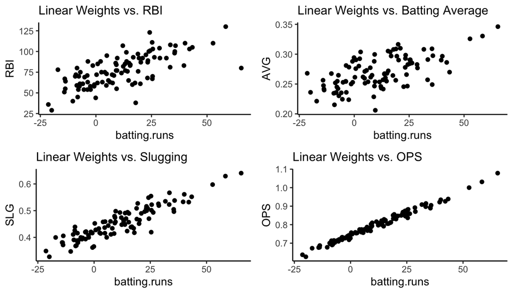

```r
library(gridExtra)

title.size = 12

p.rbi <- batting.2018 %>%
  ggplot(aes(label = name,
             x = batting.runs,
             y = RBI)) +
  geom_point() +
  labs(title = "Linear Weights vs. RBI") +
  theme_classic() +
  theme(plot.title = element_text(size = title.size))

p.avg <- batting.2018 %>%
  ggplot(aes(label = name,
             x = batting.runs,
             y = AVG)) +
  geom_point() +
  labs(title = "Linear Weights vs. Batting Average") +
  theme_classic() +
  theme(plot.title = element_text(size = title.size))


p.slg <- batting.2018 %>%
  ggplot(aes(label = name,
             x = batting.runs,
             y = SLG)) +
  geom_point() +
  labs(title = "Linear Weights vs. Slugging") +
  theme_classic() +
  theme(plot.title = element_text(size = title.size))

p.ops <- batting.2018 %>%
  ggplot(aes(label = name,
             x = batting.runs,
             y = OPS)) +
  geom_point() +
  labs(title = "Linear Weights vs. OPS") + theme_classic() +
  theme(plot.title = element_text(size = title.size))

grid.arrange(p.rbi,p.avg, p.slg, p.ops, ncol = 2)
```

```r
ggplotly(p.rbi)
```

[interactive chart not shown]

```r
ggplotly(p.avg)
```

[interactive chart not shown]

```r
ggplotly(p.slg)
```

[interactive chart not shown]

```r
ggplotly(p.ops)
```

[interactive chart not shown]

Let’s say you’re a general manager. Which statistic would you use?

What other factors would you want to consider?

In terms of $BattingRuns$, is it more important to hit for power or on base percentage?

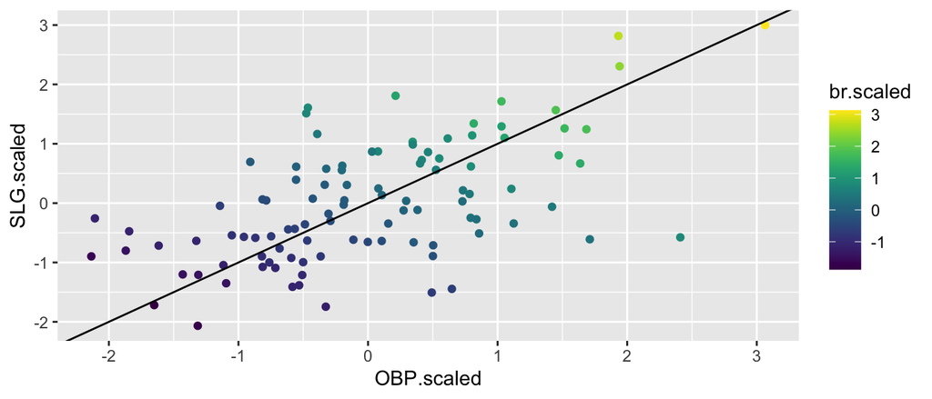

```r
library(viridis)
batting.2018 %>%
  mutate(OBP.scaled = scale(OBP),
         SLG.scaled = scale(SLG),
         br.scaled = scale(batting.runs)) %>%
  ggplot(aes(x = OBP.scaled, y = SLG.scaled, color = br.scaled)) +
  geom_point() +
  scale_color_viridis() +
  geom_abline(slope = 1, intercept = 0)
```